# Analisa Bisnis Restoran 2020

Choiril Abdul

## Persiapan

Mempersiapkan library dan dataset

```r
library(tidyverse)
library(data.table)
library(readr)
library(sunburstR)
library(d3r)

### Menentukan dataset

filePath <- "dataset/"
ft50 <- fread(paste0(filePath,"Future50.csv"))
ip100 <- fread(paste0(filePath,"Independence100.csv"))
tp250 <- fread(paste0(filePath,"Top250.csv"))
```

## Eksplorasi Analisis Data

Untuk memulai analisis data adalah mengerti tentang datanya, pertama cari tipe data yang ada, di R bisa menggunakan str() dan head() melihat 10 data pertama.

### Cek data

Dengan pengecekan ini kita bisa tipe datanya apakah integer, numeric atau character.

```r
str(ft50)
```

```
## Classes 'data.table' and 'data.frame': 50 obs. of 9 variables:
## $ Rank : int 1 2 3 4 5 6 7 8 9 10 ...
## $ Restaurant : chr "Evergreens" "Clean Juice" "Slapfish" "Clean Eatz" ...
## $ Location : chr "Seattle, Wash." "Charlotte, N.C." "Huntington Beach,
Calif." "Wilmington, N.C." ...
## $ Sales : int 24 44 21 25 49 39 24 20 24 29 ...
## $ YOY_Sales : chr "130.5%" "121.9%" "81.0%" "79.7%" ...
## $ Units : int 26 105 21 46 50 76 36 19 60 17 ...
## $ YOY_Units : chr "116.7%" "94.4%" "90.9%" "58.6%" ...
## $ Unit_Volume: int 1150 560 1370 685 1210 580 775 1260 465 1930 ...
## $ Franchising: chr "No" "Yes" "Yes" "Yes" ...
## - attr(*, ".internal.selfref")=<externalptr>
```

```r
str(ip100)
```

```
## Classes 'data.table' and 'data.frame': 100 obs. of 7 variables:
## $ Rank : int 1 2 3 4 5 6 7 8 9 10 ...
## $ Restaurant : chr "Carmine's (Times Square)" "The Boathouse Orlando" "Old
Ebbitt Grill" "LAVO Italian Restaurant & Nightclub" ...
## $ Sales : num 39080335 35218364 29104017 26916180 26900000 ...
## $ Average Check: int 40 43 33 90 62 80 103 99 87 107 ...
## $ City : chr "New York" "Orlando " "Washington" "New York" ...
## $ State : chr "N.Y." "Fla." "D.C." "N.Y." ...
## $ Meals Served : num 469803 820819 892830 198500 403000 ...
## - attr(*, ".internal.selfref")=<externalptr>
```

```r
str(tp250)
```

```
## Classes 'data.table' and 'data.frame': 250 obs. of 9 variables:
## $ Rank : int 1 2 3 4 5 6 7 8 9 10 ...
## $ Restaurant : chr "McDonald's" "Starbucks" "Chick-fil-A" "Taco Bell" ...
## $ Content : chr NA NA "While Popeyes got a lot of the chicken buzz in 2019,
Chick-fil-A had a busy year in its own right. On top of pa"| __truncated__ NA
...
## $ Sales : int 40412 21380 11320 11293 10204 10200 9762 9228 7044 5890 ...
## $ YOY_Sales : chr "4.9%" "8.6%" "13.0%" "9.0%" ...
## $ Units : int 13846 15049 2470 6766 7346 23801 5852 9630 6126 2160 ...
## $ YOY_Units : chr "-0.5%" "3.0%" "5.0%" "2.7%" ...
## $ Headquarters : chr NA NA NA NA ...
## $ Segment_Category: chr "Quick Service & Burger" "Quick Service & Coffee
Cafe" "Quick Service & Chicken" "Quick Service & Mexican" ...
## - attr(*, ".internal.selfref")=<externalptr>
```

```r
head(ft50)
```

| Rank | Restaurant | Location | Sales | YOY_Sales | Units | YOY_Units | Unit_Volume | Franchising |
| --- | --- | --- | --- | --- | --- | --- | --- | --- |
| 1 | Evergreens | Seattle, Wash. | 24 | 130.5% | 26 | 116.7% | 1150 | No |
| 2 | Clean Juice | Charlotte, N.C. | 44 | 121.9% | 105 | 94.4% | 560 | Yes |
| 3 | Slapfish | Huntington Beach, Calif. | 21 | 81.0% | 21 | 90.9% | 1370 | Yes |
| 4 | Clean Eatz | Wilmington, N.C. | 25 | 79.7% | 46 | 58.6% | 685 | Yes |
| 5 | Pokeworks | Irvine, Calif. | 49 | 77.1% | 50 | 56.3% | 1210 | Yes |
| 6 | Playa Bowls | Belmar, N.J. | 39 | 62.9% | 76 | 28.8% | 580 | Yes |

```r
head(ip100)
```

| Rank | Restaurant | Sales | Average Check | City | State | Meals Served |
| --- | --- | --- | --- | --- | --- | --- |
| 1 | Carmine's (Times Square) | 39080335 | 40 | New York | N.Y. | 469803 |
| 2 | The Boathouse Orlando | 35218364 | 43 | Orlando | Fla. | 820819 |
| 3 | Old Ebbitt Grill | 29104017 | 33 | Washington | D.C. | 892830 |
| 4 | LAVO Italian Restaurant & Nightclub | 26916180 | 90 | New York | N.Y. | 198500 |
| 5 | Bryant Park Grill & Cafe | 26900000 | 62 | New York | N.Y. | 403000 |
| 6 | Gibsons Bar & Steakhouse | 25409952 | 80 | Chicago | Ill. | 348567 |

```r
head(tp250)
```

| Rank | Restaurant | Content | Sales | YOY_Sales | Units | YOY_Units | Headquarters | Segment_Category |
| --- | --- | --- | --- | --- | --- | --- | --- | --- |
| 1 | McDonald's | NA | 40412 | 4.9% | 13846 | -0.5% | NA | Quick Service & Burger |
| 2 | Starbucks | NA | 21380 | 8.6% | 15049 | 3.0% | NA | Quick Service & Coffee Cafe |
| 3 | Chick-fil-A | While Popeyes got a lot of the chicken buzz in 2019, Chick-fil-A had a busy year in its own right. On top of passing Taco Bell and Subway to become the nation's third-largest chain, it introduced dine… | 11320 | 13.0% | 2470 | 5.0% | NA | Quick Service & Chicken |
| 4 | Taco Bell | NA | 11293 | 9.0% | 6766 | 2.7% | NA | Quick Service & Mexican |
| 5 | Burger King | NA | 10204 | 2.7% | 7346 | 0.2% | NA | Quick Service & Burger |
| 6 | Subway | NA | 10200 | -2.0% | 23801 | -4.0% | NA | Quick Service & Sandwich |

Setelah melihat tipe data dan datanya, ada beberapa yang perlu diperbaiki. Kita perbaiki satu persatu datasetnya.

### Eksplore Future 50

Kita akan mencoba eksplore data futre 50, yang berisikan perkiraan rangking 50 besar tahun depan berdasarkan data tahun 2020. Melihat data ft50, ternyata ada bebrapa kolom yang yang harus diperbaiki, seperti pemisahan data dan perubahan tipe data.

```r
ft50[, .N, Location]
```

| Location | N |
| --- | --- |
| Seattle, Wash. | 1 |
| Charlotte, N.C. | 2 |
| Huntington Beach, Calif. | 1 |
| Wilmington, N.C. | 1 |
| Irvine, Calif. | 1 |
| Belmar, N.J. | 1 |
| Blue Bell, Pa. | 1 |
| New York, N.Y. | 8 |
| Yorba Linda, Calif. | 1 |
| Louisville, Ky. | 1 |

[output cut: 29 more lines]

Dari data tersebut, negara bagian masih menjadi satu. Untuk itu perlu pemisahan.

```r
ft50_clean <- setDT(ft50)[, paste0(c("City", "State")) := tstrsplit(Location, ", ")]
```

Mendapat 2 tabel baru berupa kota dan negara bagian, pada negara bagian akan dibuat dengan penamaan yang sesuai seperti Calif. menjadi CA.

```r
### melihat negara bagian
ft50_clean[, .N, State]
```

| State | N |
| --- | --- |
| Wash. | 1 |
| N.C. | 3 |
| Calif. | 9 |
| N.J. | 1 |
| Pa. | 2 |
| N.Y. | 8 |
| Calif. | 1 |
| Ky. | 1 |
| S.C. | 1 |
| Colo. | 1 |

[output cut: 13 more lines]

```r
### Merubah negara bagian
ft50_clean$State <- gsub( "\\.", "", str_squish(str_to_lower(ft50_clean$State)))
ft50_clean[State == "ar", State := "AR"]
ft50_clean[State == "ariz", State := "AZ"]
ft50_clean[State == "ark", State := "AR"]
ft50_clean[State == "az", State := "AZ"]
ft50_clean[State == "ca", State := "CA"]
ft50_clean[State == "calif", State := "CA"]
ft50_clean[State == "co", State := "CO"]
ft50_clean[State == "colo", State := "CO"]
ft50_clean[State == "dc", State := "DC"]
ft50_clean[State == "fl", State := "FL"]
ft50_clean[State == "fla", State := "FL"]
ft50_clean[State == "ga", State := "GA"]
ft50_clean[State == "ill", State := "IL"]
ft50_clean[State == "ind", State := "IN"]
ft50_clean[State == "ky", State := "KY"]
ft50_clean[State == "mass", State := "MA"]
ft50_clean[State == "mich", State := "MI"]
ft50_clean[State == "mo", State := "MO"]
ft50_clean[State == "nc", State := "NC"]
ft50_clean[State == "ne", State := "NE"]
ft50_clean[State == "neb", State := "NE"]
ft50_clean[State == "nj", State := "NJ"]
ft50_clean[State == "ny", State := "NY"]
ft50_clean[State == "nev", State := "NV"]
ft50_clean[State == "oh", State := "OH"]
ft50_clean[State == "ohio", State := "OH"]
ft50_clean[State == "or", State := "OR"]
ft50_clean[State == "ore", State := "OR"]
ft50_clean[State == "pa", State := "PA"]
ft50_clean[State == "sc", State := "SC"]
ft50_clean[State == "tenn", State := "TN"]
ft50_clean[State == "texas", State := "TX"]
ft50_clean[State == "tn", State := "TN"]
ft50_clean[State == "tx", State := "TX"]
ft50_clean[State == "va", State := "VA"]
ft50_clean[State == "wa", State := "WA"]
ft50_clean[State == "wash", State := "WA"]
```

Selanjutnya, merubah YOY Sales dan YOY Unit dari char ke num.

```r
ft50_clean$YOY_Units <- sub("%", "", ft50_clean$YOY_Units)
ft50_clean$YOY_Sales <- sub("%", "", ft50_clean$YOY_Sales)
ft50_clean <-
  ft50_clean %>%
  mutate(YOY_Sales = as.numeric(YOY_Sales),
         YOY_Units = as.numeric(YOY_Units))
ft50_clean <- ft50_clean[,c(1,2,3,10,11,4:9)]
ft50_clean <- select(ft50_clean, -Location)
```

Data sudah clean, selanjutnya mencoba melihat ringkasan data ft50.

```r
### Cek tipe data
str(ft50_clean)
```

```
## Classes 'data.table' and 'data.frame': 50 obs. of 10 variables:
## $ Rank : int 1 2 3 4 5 6 7 8 9 10 ...
## $ Restaurant : chr "Evergreens" "Clean Juice" "Slapfish" "Clean Eatz" ...
## $ City : chr "Seattle" "Charlotte" "Huntington Beach" "Wilmington" ...
## $ State : chr "WA" "NC" "CA" "NC" ...
## $ Sales : int 24 44 21 25 49 39 24 20 24 29 ...
## $ YOY_Sales : num 130.5 121.9 81 79.7 77.1 ...
## $ Units : int 26 105 21 46 50 76 36 19 60 17 ...
## $ YOY_Units : num 116.7 94.4 90.9 58.6 56.3 ...
## $ Unit_Volume: int 1150 560 1370 685 1210 580 775 1260 465 1930 ...
## $ Franchising: chr "No" "Yes" "Yes" "Yes" ...
## - attr(*, ".internal.selfref")=<externalptr>
```

```r
### Ringkasan data
summary(ft50_clean)
```

```
##       Rank        Restaurant            City              State
##  Min.   : 1.00   Length:50          Length:50          Length:50
##  1st Qu.:13.25   Class :character   Class :character   Class :character
##  Median :25.50   Mode  :character   Mode  :character   Mode  :character
##  Mean   :25.50
##  3rd Qu.:37.75
##  Max.   :50.00
##      Sales         YOY_Sales          Units         YOY_Units
##  Min.   :20.00   Min.   : 14.40   Min.   :  7.0   Min.   :  4.00
##  1st Qu.:24.25   1st Qu.: 20.90   1st Qu.: 16.0   1st Qu.: 14.30
##  Median :34.50   Median : 25.50   Median : 27.0   Median : 19.90
##  Mean   :33.78   Mean   : 33.70   Mean   : 34.7   Mean   : 27.45
##  3rd Qu.:42.00   3rd Qu.: 33.83   3rd Qu.: 45.5   3rd Qu.: 32.67
##  Max.   :49.00   Max.   :130.50   Max.   :105.0   Max.   :116.70
##   Unit_Volume     Franchising
##  Min.   : 465.0   Length:50
##  1st Qu.: 867.5   Class :character
##  Median :1260.0   Mode  :character
##  Mean   :1592.6
##  3rd Qu.:2020.0
##  Max.   :4300.0
```

```r
### Cek data null
sum(is.na(ft50_clean))
```

```
## [1] 0
```

### Membuat plot

Mari kita cek, berapa persen Restoran yang Franchising dalam future 50 ini?

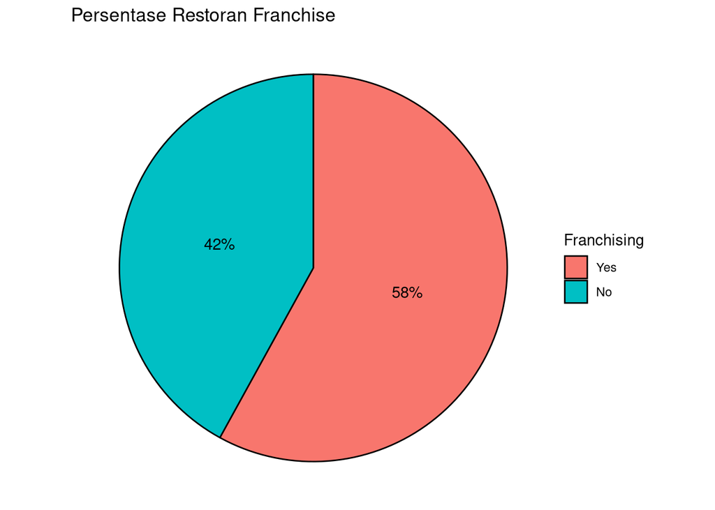

```r
franchise <- data.frame(sort(table(ft50_clean$Franchising),decreasing = TRUE ))
setnames(franchise,c("Franchising","Jumlah"))

pct <- round(100*franchise$Jumlah/sum(franchise$Jumlah))

ggplot(data = franchise, aes(x = "", y = -Jumlah,
                           fill = Franchising)) +
  geom_bar(stat = "identity", color = "black") +
  labs(title = "Persentase Restoran Franchise") +
  coord_polar("y") +
  geom_text(aes(label =paste0(pct, "%")), position = position_stack(vjust = 0.5)) +
  theme_void()
```

Selanjutnya kita lihat perbandingan total YOY Sales antara Restoran Franchise dan tidak.

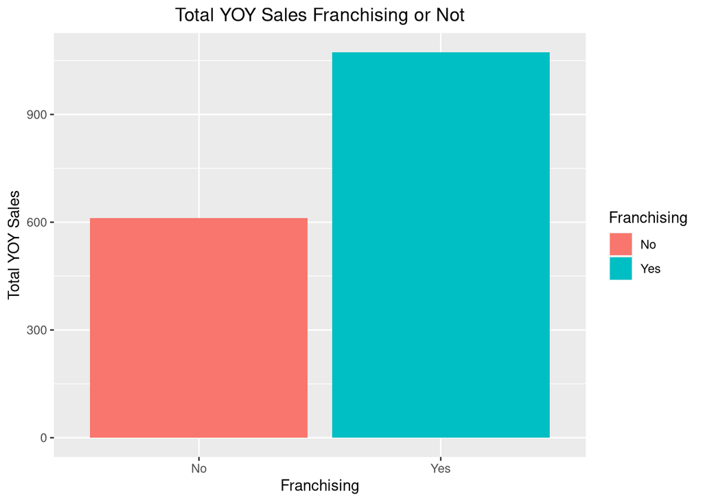

```r
yoysalesbyfranchise <- aggregate(ft50_clean$YOY_Sales, by=list(franchising=ft50_clean$Franchising), FUN=sum)
setnames(yoysalesbyfranchise,c("Franchising","Total_YOY_Sales"))

ggplot(yoysalesbyfranchise, aes(x=Franchising, y=Total_YOY_Sales, fill=Franchising)) +
  labs(title="Total YOY Sales Franchising or Not",
        x ="Franchising", y = "Total YOY Sales") +
  geom_bar(stat="identity", position=position_dodge()) +
  theme(plot.title = element_text(hjust = 0.5))
```

Dari grafik tersebut, restoran yang masuk Future 50 mengindikasikan bahwa Restoran Waralaba memiliki penjualan yang cukup banyak selama pandemi ini.

### Eksplore Independence 100

Sekarang kita coba eksplorasi 100 restoran independen. Tapi sebelum kita lakukan cleansing data terlebih dahulu.

```r
### Cek data
str(ip100)
```

```
## Classes 'data.table' and 'data.frame': 100 obs. of 7 variables:
## $ Rank : int 1 2 3 4 5 6 7 8 9 10 ...
## $ Restaurant : chr "Carmine's (Times Square)" "The Boathouse Orlando" "Old
Ebbitt Grill" "LAVO Italian Restaurant & Nightclub" ...
## $ Sales : num 39080335 35218364 29104017 26916180 26900000 ...
## $ Average Check: int 40 43 33 90 62 80 103 99 87 107 ...
## $ City : chr "New York" "Orlando " "Washington" "New York" ...
## $ State : chr "N.Y." "Fla." "D.C." "N.Y." ...
## $ Meals Served : num 469803 820819 892830 198500 403000 ...
## - attr(*, ".internal.selfref")=<externalptr>
```

```r
head(ip100)
```

| Rank | Restaurant | Sales | Average Check | City | State | Meals Served |
| --- | --- | --- | --- | --- | --- | --- |
| 1 | Carmine's (Times Square) | 39080335 | 40 | New York | N.Y. | 469803 |
| 2 | The Boathouse Orlando | 35218364 | 43 | Orlando | Fla. | 820819 |
| 3 | Old Ebbitt Grill | 29104017 | 33 | Washington | D.C. | 892830 |
| 4 | LAVO Italian Restaurant & Nightclub | 26916180 | 90 | New York | N.Y. | 198500 |
| 5 | Bryant Park Grill & Cafe | 26900000 | 62 | New York | N.Y. | 403000 |
| 6 | Gibsons Bar & Steakhouse | 25409952 | 80 | Chicago | Ill. | 348567 |

Ternyata negara bagian masih menggunkan singkatan yang kurang sesuai dengan singakatan standarnya, markicek, mari kita cek.

```r
### Cek data
ip100[, .N, State]
```

| State | N |
| --- | --- |
| N.Y. | 21 |
| Fla. | 9 |
| D.C. | 9 |
| Ill. | 18 |
| Nev. | 11 |
| N.C. | 1 |
| Ind. | 2 |
| Texas | 3 |
| Pa. | 1 |
| Calif. | 12 |

[output cut: 9 more lines]

Ada 19 negara bagian yang harus di cleansing.

```r
ip100_clean <- ip100
ip100_clean$State <- gsub( "\\.", "", str_squish(str_to_lower(ip100$State)))
ip100_clean[State == "calif", State := "CA"]
ip100_clean[State == "colo", State := "CO"]
ip100_clean[State == "dc", State := "DC"]
ip100_clean[State == "fla", State := "FL"]
ip100_clean[State == "ga", State := "GA"]
ip100_clean[State == "ill", State := "IL"]
ip100_clean[State == "ind", State := "IN"]
ip100_clean[State == "mass", State := "MA"]
ip100_clean[State == "mich", State := "MI"]
ip100_clean[State == "mo", State := "MO"]
ip100_clean[State == "nc", State := "NC"]
ip100_clean[State == "nj", State := "NJ"]
ip100_clean[State == "ny", State := "NY"]
ip100_clean[State == "nev", State := "NV"]
ip100_clean[State == "ore", State := "OR"]
ip100_clean[State == "pa", State := "PA"]
ip100_clean[State == "tenn", State := "TN"]
ip100_clean[State == "texas", State := "TX"]
ip100_clean[State == "va", State := "VA"]
```

Setelah cleansing, kita lihat summary datanya.

```r
summary(ip100_clean)
```

```
##       Rank         Restaurant            Sales          Average Check
##  Min.   :  1.00   Length:100         Min.   :11391678   Min.   : 17.00
##  1st Qu.: 25.75   Class :character   1st Qu.:14094836   1st Qu.: 39.00
##  Median : 50.50   Mode  :character   Median :17300776   Median : 65.50
##  Mean   : 50.50                      Mean   :17833434   Mean   : 69.05
##  3rd Qu.: 75.25                      3rd Qu.:19903916   3rd Qu.: 95.00
##  Max.   :100.00                      Max.   :39080335   Max.   :194.00
##      City              State            Meals Served
##  Length:100         Length:100         Min.   : 87070
##  Class :character   Class :character   1st Qu.:189492
##  Mode  :character   Mode  :character   Median :257097
##                                        Mean   :317167
##                                        3rd Qu.:372079
##                                        Max.   :959026
```

Rata-rata penjualan dari 100 Restoran Independen adalah 17833434 dengan penjualan paling sedikit 11391678 dan penjualan paling banyak 39080335. Dan rata-rata menyajikan makanan sebanyak 317167.

### Membuat plot Independen 100

Histogram persebaran 100 Restoran independen di Amerika Serikat.

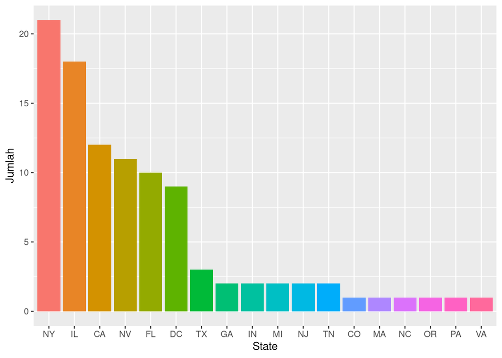

```r
sebar <- data.frame(sort(table(ip100_clean$State),decreasing = TRUE ))
setnames(sebar,c("State","Jumlah"))

ggplot(sebar, aes(x=State, y=Jumlah, fill=State)) +
  geom_bar(stat="identity", position=position_dodge()) +
  theme(legend.position="none", plot.title = element_text(hjust = 0.5)) +
  scale_colour_brewer(type = "seq", palette = "Spectral")
```

```r
salesny <-
  ip100_clean %>%
  filter(State == "NY")
mean(salesny$Sales)
```

```
## [1] 19355896
```

Dari grafik tersebut, sebanyak 21 Restoran independen berada di New York dengan rata-rata penjualan 19355896.

### Eksplore Top 250

Data terakhir dari [Restaurant Business Rankings 2020](https://www.kaggle.com/michau96/restaurant-business-rankings-2020), yaitu data Top 250 yang berisi 250 Restoran yang bagus selama tahun 2020. Mari kita cek datanya.

```r
### Cek data top 250
str(tp250)
```

```
## Classes 'data.table' and 'data.frame': 250 obs. of 9 variables:
## $ Rank : int 1 2 3 4 5 6 7 8 9 10 ...
## $ Restaurant : chr "McDonald's" "Starbucks" "Chick-fil-A" "Taco Bell" ...
## $ Content : chr NA NA "While Popeyes got a lot of the chicken buzz in 2019,
Chick-fil-A had a busy year in its own right. On top of pa"| __truncated__ NA
...
## $ Sales : int 40412 21380 11320 11293 10204 10200 9762 9228 7044 5890 ...
## $ YOY_Sales : chr "4.9%" "8.6%" "13.0%" "9.0%" ...
## $ Units : int 13846 15049 2470 6766 7346 23801 5852 9630 6126 2160 ...
## $ YOY_Units : chr "-0.5%" "3.0%" "5.0%" "2.7%" ...
## $ Headquarters : chr NA NA NA NA ...
## $ Segment_Category: chr "Quick Service & Burger" "Quick Service & Coffee
Cafe" "Quick Service & Chicken" "Quick Service & Mexican" ...
## - attr(*, ".internal.selfref")=<externalptr>
```

```r
head(tp250)
```

| Rank | Restaurant | Content | Sales | YOY_Sales | Units | YOY_Units | Headquarters | Segment_Category |
| --- | --- | --- | --- | --- | --- | --- | --- | --- |
| 1 | McDonald's | NA | 40412 | 4.9% | 13846 | -0.5% | NA | Quick Service & Burger |
| 2 | Starbucks | NA | 21380 | 8.6% | 15049 | 3.0% | NA | Quick Service & Coffee Cafe |
| 3 | Chick-fil-A | While Popeyes got a lot of the chicken buzz in 2019, Chick-fil-A had a busy year in its own right. On top of passing Taco Bell and Subway to become the nation's third-largest chain, it introduced dine… | 11320 | 13.0% | 2470 | 5.0% | NA | Quick Service & Chicken |
| 4 | Taco Bell | NA | 11293 | 9.0% | 6766 | 2.7% | NA | Quick Service & Mexican |
| 5 | Burger King | NA | 10204 | 2.7% | 7346 | 0.2% | NA | Quick Service & Burger |
| 6 | Subway | NA | 10200 | -2.0% | 23801 | -4.0% | NA | Quick Service & Sandwich |

Ternyata ada beberaa yang perlu dicleansing seperti YOY Unit, YOY Sales dan Segemen Kategori. Pertama kita ubah YOY Sales dan YOY Unit.

```r
tp250_clean <- tp250
tp250_clean$YOY_Units <- sub("%", "", tp250_clean$YOY_Units)
tp250_clean$YOY_Sales <- sub("%", "", tp250_clean$YOY_Sales)
tp250_clean <-
  tp250_clean %>%
  mutate(YOY_Sales = as.numeric(YOY_Sales),
         YOY_Units = as.numeric(YOY_Units))
```

Kita lihat lagi data segmen kategorinya, berapa banyak segmennya.

```r
tp250_clean[, .N, Segment_Category]
```

| Segment_Category | N |
| --- | --- |
| Quick Service & Burger | 13 |
| Quick Service & Coffee Cafe | 4 |
| Quick Service & Chicken | 6 |
| Quick Service & Mexican | 2 |
| Quick Service & Sandwich | 4 |
| Quick Service & Pizza | 8 |
| Fast Casual & Bakery Cafe | 1 |
| Fast Casual & Mexican | 3 |
| Casual Dining & Italian/Pizza | 4 |
| Casual Dining & Varied Menu | 9 |

[output cut: 38 more lines]

Ternyata ada 48 segment category yang harus kita olah agar dapat dianalisa lebih lanjut. Kita buat kolom baru yang berisi kategori dari restoran.

```r
tp250_clean$Category <- paste(tp250_clean$Segment_Category)

tp250_clean[Category == "Quick Service & Burger", Category := "Burger"]
tp250_clean[Category == "Quick Service & Coffee Cafe", Category := "Cafe"]
tp250_clean[Category == "Quick Service & Chicken", Category := "Chicken"]
tp250_clean[Category == "Quick Service & Mexican", Category := "Mexican"]
tp250_clean[Category == "Quick Service & Sandwich", Category := "Sandwich"]
tp250_clean[Category == "Quick Service & Pizza", Category := "Pizza"]
tp250_clean[Category == "Fast Casual & Bakery Cafe", Category := "Cafe"]
tp250_clean[Category == "Fast Casual & Mexican", Category := "Mexican"]
tp250_clean[Category == "Casual Dining & Italian/Pizza", Category := "Pizza"]
tp250_clean[Category == "Casual Dining & Varied Menu", Category := "Varied Menu"]
tp250_clean[Category == "Fast Casual & Asian/Noodle", Category := "Asian"]
tp250_clean[Category == "Quick Service & Frozen Desserts", Category := "Desserts"]
tp250_clean[Category == "Casual Dining & Sports Bar", Category := "Sports Bar"]
tp250_clean[Category == "Family Dining & Family Style", Category := "Family"]
tp250_clean[Category == "Casual Dining & Steak", Category := "Steak"]
tp250_clean[Category == "Casual Dining & Seafood", Category := "Seafood"]
tp250_clean[Category == "Fast Casual & Sandwich", Category := "Sandwich"]
tp250_clean[Category == "Fast Casual & Chicken", Category := "Chicken"]
tp250_clean[Category == "Quick Service & Family Casual", Category := "Family"]
tp250_clean[Category == "Fast Casual & Burger", Category := "Burger"]
tp250_clean[Category == "Casual Dining & Asian", Category := "Asian"]
tp250_clean[Category == "Quick Service & Snack", Category := "Snack"]
tp250_clean[Category == "Quick Service & Beverage", Category := "Drinks"]
tp250_clean[Category == "Quick Service & Seafood", Category := "Seafood"]
tp250_clean[Category == "Quick Service & Bakery Cafe", Category := "Cafe"]
tp250_clean[Category == "Fast Casual & Pizza", Category := "Pizza"]
tp250_clean[Category == "Fine Dining & Steak", Category := "Steak"]
tp250_clean[Category == "Italian/Pizza", Category := "Pizza"]
tp250_clean[Category == "Frozen Desserts", Category := "Desserts"]
tp250_clean[Category == "Coffee Cafe", Category := "Cafe"]
tp250_clean[Category == "BBQ", Category := "Meat"]
tp250_clean[Category == "Bakery Cafe", Category := "Cafe"]
tp250_clean[Category == "Asian/Noodle", Category := "Asian"]
tp250_clean[Category == "Family Casual", Category := "Family"]
tp250_clean[Category == "Family Style", Category := "Family"]
```

Kategori Restoran sudah kita buat, selanjutnya kita akan membuat 2 kolom baru tentang trend penjualan dan cabang apakah negatif atau positif.

```r
tp250_clean$Sales_Year <- ifelse(tp250_clean$YOY_Sales > 0, 'Positive', 'Negative')
tp250_clean$Unit_Stat <- ifelse(tp250_clean$YOY_Units > 0, 'Positive', 'Negative')
```

Biar terlihat rapi, kita buang beberapa kolom yang terdapat nilai NA. Seperti kolom Content dan Headquarters.

```r
tp250_clean <- select(tp250_clean, -Content, -Headquarters)
```

Setelah data cleansing, kita lihat summary datanya.

```r
### Ringkasan data
summary(tp250_clean)
```

```
##       Rank         Restaurant            Sales           YOY_Sales
##  Min.   :  1.00   Length:250         Min.   :  126.0   Min.   :-21.200
##  1st Qu.: 63.25   Class :character   1st Qu.:  181.0   1st Qu.: -2.375
##  Median :125.50   Mode  :character   Median :  330.0   Median :  2.200
##  Mean   :125.50                      Mean   : 1242.7   Mean   :  2.938
##  3rd Qu.:187.75                      3rd Qu.:  724.8   3rd Qu.:  6.575
##  Max.   :250.00                      Max.   :40412.0   Max.   : 39.500
##      Units           YOY_Units       Segment_Category     Category
##  Min.   :   13.0   Min.   :-32.800   Length:250         Length:250
##  1st Qu.:   85.0   1st Qu.: -2.025   Class :character   Class :character
##  Median :  207.0   Median :  0.000   Mode  :character   Mode  :character
##  Mean   :  850.1   Mean   :  1.219
##  3rd Qu.:  555.2   3rd Qu.:  3.475
##  Max.   :23801.0   Max.   : 38.500
##   Sales_Year         Unit_Stat
##  Length:250         Length:250
##  Class :character   Class :character
##  Mode  :character   Mode  :character
##
##
##
```

```r
### Cek data null
sum(is.na(tp250_clean))
```

```
## [1] 0
```

Dari data tersebut sudah tidak ada data NA, sedangkan rata-rata penjualannya adalah 1242.7 atau 1243 dan rata-rata cabangnya adalah 850. Langkah selanjutnya adalah membuat grafik dari data Restoran Top 250.

### Membuat plot Top 250

Kita lihat status penjualan YOY Sales selama 2019-2020 dari 250 Restoran.

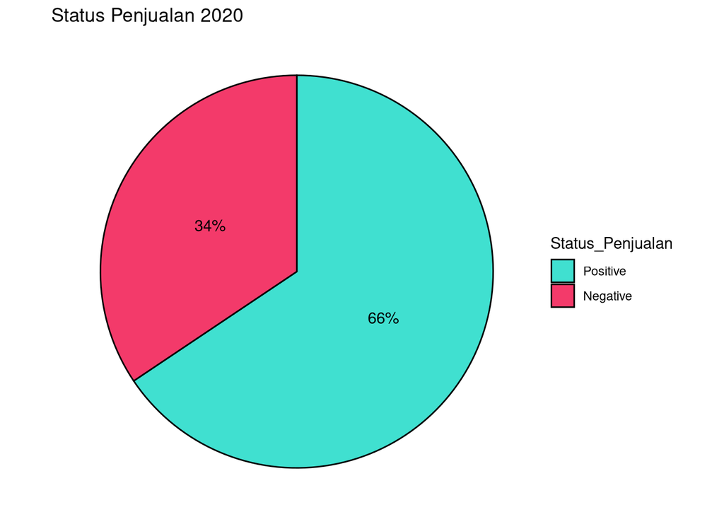

```r
sellstat <- data.frame(sort(table(tp250_clean$Sales_Year),decreasing = TRUE ))
setnames(sellstat,c("Status_Penjualan","Jumlah"))

pct <- round(100*sellstat$Jumlah/sum(sellstat$Jumlah))

ggplot(data = sellstat, aes(x = "", y = -Jumlah,
                           fill = Status_Penjualan)) +
  geom_bar(stat = "identity", color = "black") +
  labs(title = "Status Penjualan 2020") +
  coord_polar("y") +
  geom_text(aes(label =paste0(pct, "%")), position = position_stack(vjust = 0.5)) +
  theme_void() +
  scale_fill_manual(values=c("#40E0D0", "#F33A6A"))
```

Dari diagram tersebut, selama 2020 penjualan sebanyak 34% dari 250 restoran penjualannya berstatus negatif atau mengalami penurunan penjualan.

Selanjutnya coba kita lihat kategori dan sub kategori restoran.

```r
sb <- tp250_clean %>%
  select(Category, Segment_Category, Restaurant) %>%
  mutate_at(vars(2,3), funs(gsub("-", "", .))) %>%
  mutate(
    path = paste(Category, Segment_Category, Restaurant, sep = "-")
  ) %>%
  slice(1:250) %>%
  mutate(
    V2 = 1
  )
sunbrst <- sund2b(data = data.frame(xtabs(V2~path, sb)), rootLabel = 'Top 250 Restoran')
sunbrst
```

[interactive chart not shown]

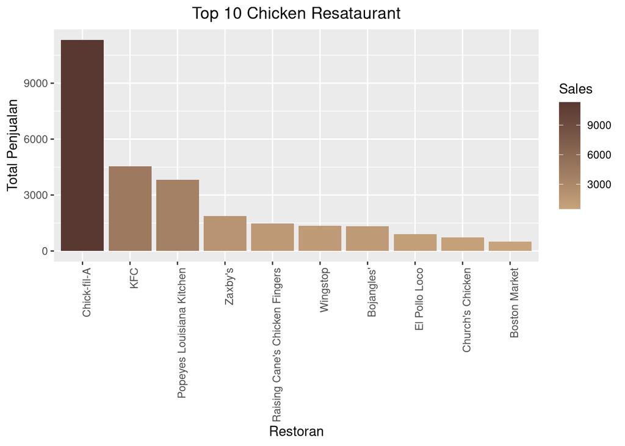

```r
### Mencari total penjualan
moresale <- aggregate(tp250_clean$YOY_Sales, .SD[1:10], by=list(Category=tp250_clean$Category), FUN=sum)

chicken <- tp250_clean[Category == "Chicken", .SD[1:10]]
mexican <- tp250_clean[Category == "Mexican", .SD[1:10]]
burger <- tp250_clean[Category == "Burger", .SD[1:10]]
steak <- tp250_clean[Category == "Steak", .SD[1:10]]
pizza <- tp250_clean[Category == "Pizza", .SD[1:10]]

### Plot
ggplot(chicken, aes(x= reorder(Restaurant, -Sales), y=Sales, fill=Sales)) +
  labs(title="Top 10 Chicken Resataurant",
        x ="Restoran", y = "Total Penjualan") +
  geom_bar(stat="identity", position=position_dodge()) +
  scale_fill_gradient(low="#c7a37c",high="#583831") +
  theme(plot.title = element_text(hjust = 0.5), axis.text.x = element_text(angle = 90, hjust = 1))
```

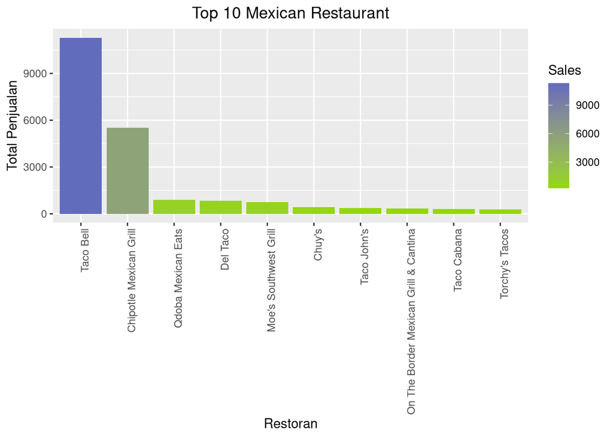

```r
ggplot(mexican, aes(x= reorder(Restaurant, -Sales), y=Sales, fill=Sales)) +
  labs(title="Top 10 Mexican Restaurant",
        x ="Restoran", y = "Total Penjualan") +
  geom_bar(stat="identity", position=position_dodge()) +
  scale_fill_gradient(low="#95d800",high="#626cbd") +
  theme(plot.title = element_text(hjust = 0.5), axis.text.x = element_text(angle = 90, hjust = 1))
```

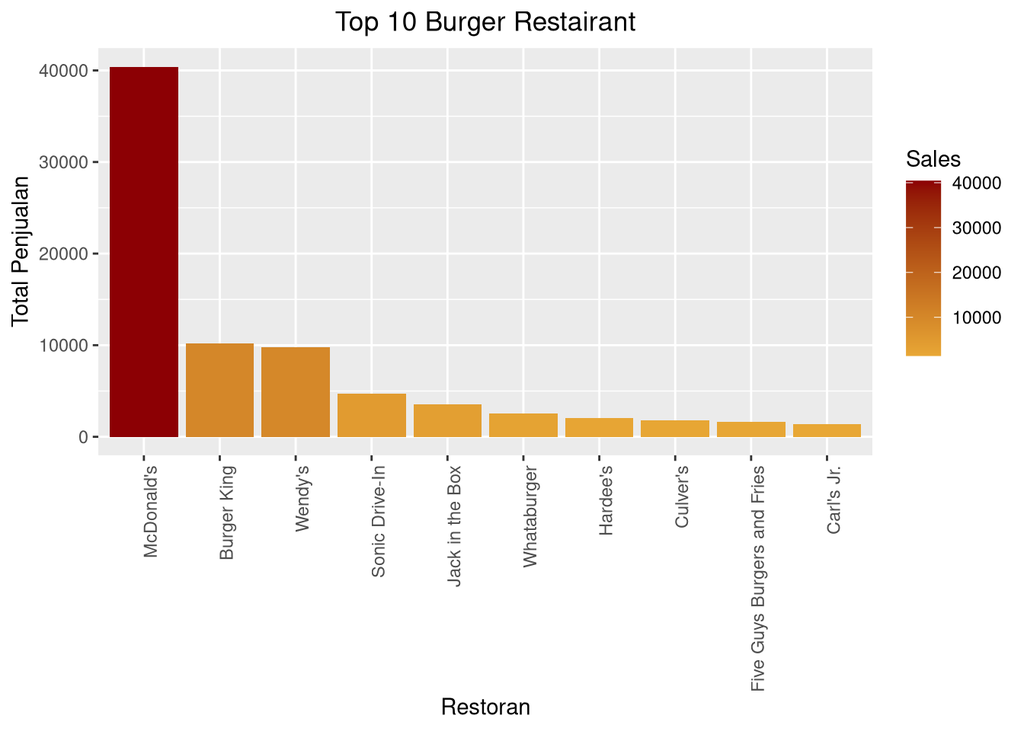

```r
ggplot(burger, aes(x= reorder(Restaurant, -Sales), y=Sales, fill=Sales)) +
  labs(title="Top 10 Burger Restairant",
        x ="Restoran", y = "Total Penjualan") +
  geom_bar(stat="identity", position=position_dodge()) +
  scale_fill_gradient(low="#e8a735",high="#8c0004") +
  theme(plot.title = element_text(hjust = 0.5), axis.text.x = element_text(angle = 90, hjust = 1))
```

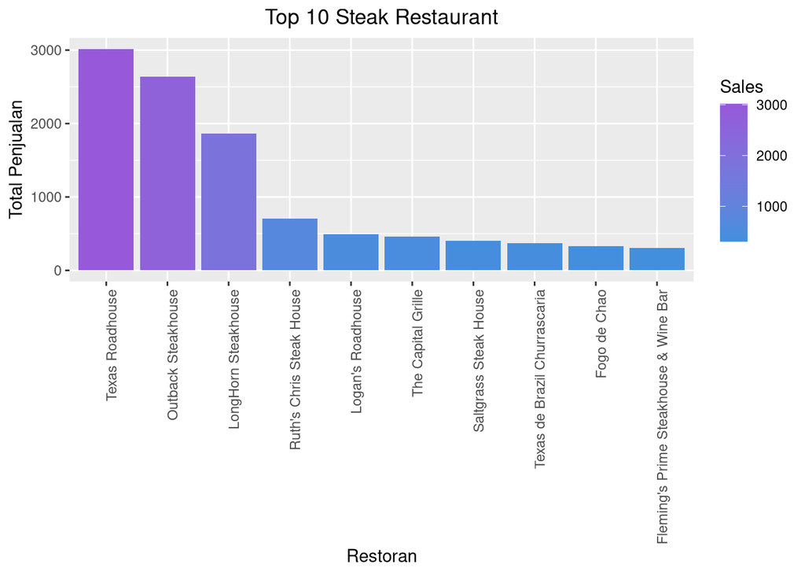

```r
ggplot(steak, aes(x= reorder(Restaurant, -Sales), y=Sales, fill=Sales)) +
  labs(title="Top 10 Steak Restaurant",
        x ="Restoran", y = "Total Penjualan") +
  geom_bar(stat="identity", position=position_dodge()) +
  scale_fill_gradient(low="#428fdd",high="#9758da") +
  theme(plot.title = element_text(hjust = 0.5), axis.text.x = element_text(angle = 90, hjust = 1))
```

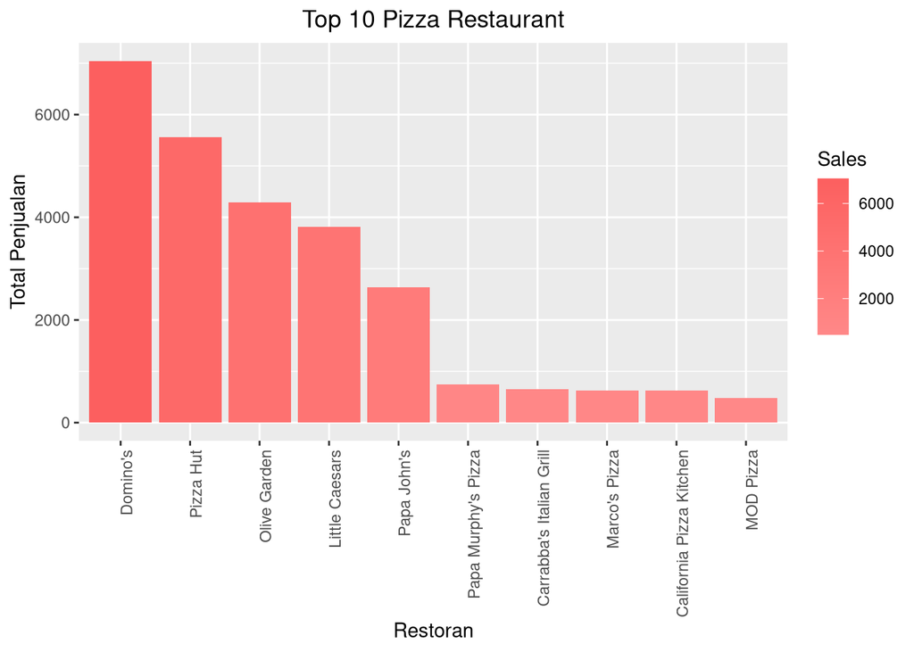

```r
ggplot(pizza, aes(x= reorder(Restaurant, -Sales), y=Sales, fill=Sales)) +
  labs(title="Top 10 Pizza Restaurant",
        x ="Restoran", y = "Total Penjualan") +
  geom_bar(stat="identity", position=position_dodge()) +
  scale_fill_gradient(low="#ff8888",high="#fc5f5f") +
  theme(plot.title = element_text(hjust = 0.5), axis.text.x = element_text(angle = 90, hjust = 1))
```

Selanjutnya kita akan membandingkan berapa banyak Restoran kecil dan Restoran besar pada top 250.

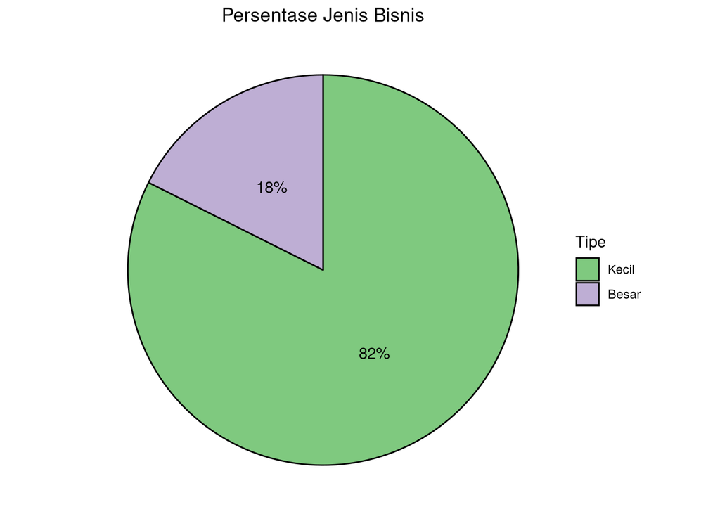

```r
tp250_clean$Type <- ifelse(tp250_clean$Units > mean(tp250_clean$Units), 'Besar', 'Kecil')

bisnis <- data.frame(sort(table(tp250_clean$Type),decreasing = TRUE ))
setnames(bisnis,c("Tipe","Jumlah"))

pct <- round(100*bisnis$Jumlah/sum(bisnis$Jumlah))

ggplot(data = bisnis, aes(x = "", y = -Jumlah,
                           fill = Tipe)) +
  geom_bar(stat = "identity", color = "black") +
  labs(title = "Persentase Jenis Bisnis") +
  coord_polar("y") +
  geom_text(aes(label =paste0(pct, "%")), position = position_stack(vjust = 0.5)) +
  theme_void() +
  scale_fill_brewer(palette = "Accent") +
  theme(plot.title = element_text(hjust = 0.5), legend.position="right")
```

Dari diagram tersebut, dapat kita ketahui bahwa selama pandemi Restoran skala kecil sebanyak 206 restoran masih dapat survive dan masuk kedalam top 250.